# Programming assignment 4

**Author**: Diana Sanchez **Date**: Last update: 2022-04-18 23:52:16

# Overview

My hypotheses below reflect what I learned this semester and previous knowledge from other courses. In addition, the reading assignments and class discussions have allowed me to make the following predictions.

1. **The L2 Learners will demonstrate vowel production that is influenced by their English vowel inventory.** This means that the participant’s vowel will differentiate from that of the bilingual speaker when attempting to produce the pseudo-Spanish words. For example, the L2 participant may produce the Spanish /e/ as /ei/. As a result, the spectrogram may demonstrate these differences. When considering a theoretical framework, such as Flege’s Speech Learning Model, it is anticipated that the production between the Bilinguals and L2 Learners will differ due to the L2 Learners’ activation of the English phonetic category (Amengual, 2012).
2. **It is hypothesized that the bilingual speakers’ vowel analyses will differentiate from one another due to the variety of English and Spanish influences each may have experienced.**
3. **It is hypothesized that VOT for the bilingual participants will be shorter when compared to L2 Spanish Learners.**

# Prep

## Libraries

```r
library("plyr")
library("dplyr")
```

```r
library("ggplot2")
library("readr")
library("here")
library("tidyr")
library("stringr")
library("kableExtra")
library("purrr")
library("knitr")
```

## Load data

```r
# You need to get all the files in the 'data' directory and combine them
# Check previous examples we did in class

bi01 <- read.csv(file = "/Users/princesa/Desktop/pa_4/data/bi01.csv")
bi02 <- read.csv(file = "/Users/princesa/Desktop/pa_4/data/bi02.csv")
bi03 <- read.csv(file = "/Users/princesa/Desktop/pa_4/data/bi03.csv")

ne01 <- read.csv(file = "/Users/princesa/Desktop/pa_4/data/ne01.csv")
ne02 <- read.csv(file = "/Users/princesa/Desktop/pa_4/data/ne02.csv")
ne03 <- read.csv(file = "/Users/princesa/Desktop/pa_4/data/ne03.csv")
```

## Raw Data Summaries

```r
bi01 %>%
  summarize(
    Meanf1 = mean(f1),
    Meanf2 = mean(f2),
    MeanVOT = mean(vot),
     SD_f1 = sd(f1),
    SD_f2 = sd(f2),
    SD_VOT = sd(vot)) %>%

  kbl(caption = "Bilingual Data Summary bi01") %>%
  kable_classic(full_width = F, html_font = "Cambria")
```

Bilingual Data Summary bi01

| Meanf1 | Meanf2 | MeanVOT | SD_f1 | SD_f2 | SD_VOT |
| --- | --- | --- | --- | --- | --- |
| 520.2511 | 1727.237 | 26.19733 | 138.3988 | 666.6207 | 23.57278 |

```r
summary(bi01) %>%
  kbl(caption = "Bilingual Data Summary bi01") %>%
  kable_classic(full_width = F, html_font = "Cambria")
```

Bilingual Data Summary bi01

|  | fileID | f1 | f2 | vot | notes |
| --- | --- | --- | --- | --- | --- |
|  | Length:45 | Min. :231.7 | Min. : 831.2 | Min. : 10.16 | Mode:logical |
|  | Class :character | 1st Qu.:438.7 | 1st Qu.:1073.2 | 1st Qu.: 16.22 | NA’s:45 |
|  | Mode :character | Median :511.0 | Median :1591.1 | Median : 19.27 | NA |
|  | NA | Mean :520.3 | Mean :1727.2 | Mean : 26.20 | NA |
|  | NA | 3rd Qu.:598.5 | 3rd Qu.:2361.3 | 3rd Qu.: 27.74 | NA |
|  | NA | Max. :893.0 | Max. :2765.7 | Max. :167.71 | NA |

```r
bi02 %>%
  summarize(
    Meanf1 = mean(f1),
    Meanf2 = mean(f2),
    MeanVOT = mean(vot),
     SD_f1 = sd(f1),
    SD_f2 = sd(f2),
    SD_VOT = sd(vot)) %>%

  kbl(caption = "Bilingual Data Summary bi02") %>%
  kable_classic(full_width = F, html_font = "Cambria")
```

Bilingual Data Summary bi02

| Meanf1 | Meanf2 | MeanVOT | SD_f1 | SD_f2 | SD_VOT |
| --- | --- | --- | --- | --- | --- |
| 521.3113 | 1573.975 | 16.07489 | 135.4567 | 677.4419 | 6.628824 |

```r
summary(bi02) %>%
  kbl(caption = "Bilingual Data Summary bi02") %>%
  kable_classic(full_width = F, html_font = "Cambria")
```

Bilingual Data Summary bi02

|  | fileID | f1 | f2 | vot | notes |
| --- | --- | --- | --- | --- | --- |
|  | Length:45 | Min. :286.3 | Min. : 780.0 | Min. : 4.43 | Mode:logical |
|  | Class :character | 1st Qu.:462.4 | 1st Qu.: 945.3 | 1st Qu.:11.39 | NA’s:45 |
|  | Mode :character | Median :500.0 | Median :1497.6 | Median :16.07 | NA |
|  | NA | Mean :521.3 | Mean :1574.0 | Mean :16.07 | NA |
|  | NA | 3rd Qu.:582.0 | 3rd Qu.:2292.1 | 3rd Qu.:20.95 | NA |
|  | NA | Max. :808.4 | Max. :2752.3 | Max. :31.47 | NA |

```r
bi03 %>%
  summarize(
    Meanf1 = mean(f1),
    Meanf2 = mean(f2),
    MeanVOT = mean(vot),
     SD_f1 = sd(f1),
    SD_f2 = sd(f2),
    SD_VOT = sd(vot)) %>%

  kbl(caption = "Bilingual Data Summary bi03") %>%
  kable_classic(full_width = F, html_font = "Cambria")
```

Bilingual Data Summary bi03

| Meanf1 | Meanf2 | MeanVOT | SD_f1 | SD_f2 | SD_VOT |
| --- | --- | --- | --- | --- | --- |
| 625.8596 | 1736.537 | 16.83622 | 283.3549 | 695.766 | 7.660761 |

```r
summary(bi03) %>%
  kbl(caption = "Bilingual Data Summary bi03") %>%
  kable_classic(full_width = F, html_font = "Cambria")
```

Bilingual Data Summary bi03

|  | fileID | f1 | f2 | vot | notes |
| --- | --- | --- | --- | --- | --- |
|  | Length:45 | Min. : 259.6 | Min. : 730.2 | Min. : 6.97 | Mode:logical |
|  | Class :character | 1st Qu.: 414.5 | 1st Qu.:1058.5 | 1st Qu.:10.16 | NA’s:45 |
|  | Mode :character | Median : 537.3 | Median :1681.0 | Median :15.27 | NA |
|  | NA | Mean : 625.9 | Mean :1736.5 | Mean :16.84 | NA |
|  | NA | 3rd Qu.: 791.3 | 3rd Qu.:2393.6 | 3rd Qu.:21.68 | NA |
|  | NA | Max. :1817.7 | Max. :2946.8 | Max. :34.40 | NA |

```r
ne01 %>%
  summarize(
    Meanf1 = mean(f1),
    Meanf2 = mean(f2),
    MeanVOT = mean(vot),
    SD_f1 = sd(f1),
    SD_f2 = sd(f2),
    SD_VOT = sd(vot)) %>%

  kbl(caption = "L2 Learner Data Summary ne01") %>%
  kable_classic(full_width = F, html_font = "Cambria")
```

L2 Learner Data Summary ne01

| Meanf1 | Meanf2 | MeanVOT | SD_f1 | SD_f2 | SD_VOT |
| --- | --- | --- | --- | --- | --- |
| 617.9978 | 1870.893 | 28.63311 | 244.8154 | 725.9127 | 15.29958 |

```r
summary(ne01) %>%
  kbl(caption = "L2 Learner Data Summary ne01") %>%
  kable_classic(full_width = F, html_font = "Cambria")
```

L2 Learner Data Summary ne01

|  | fileID | f1 | f2 | vot | notes |
| --- | --- | --- | --- | --- | --- |
|  | Length:45 | Min. : 355.3 | Min. : 999.1 | Min. : 7.50 | Mode:logical |
|  | Class :character | 1st Qu.: 423.3 | 1st Qu.:1079.5 | 1st Qu.:14.08 | NA’s:45 |
|  | Mode :character | Median : 525.1 | Median :1718.4 | Median :27.76 | NA |
|  | NA | Mean : 618.0 | Mean :1870.9 | Mean :28.63 | NA |
|  | NA | 3rd Qu.: 834.4 | 3rd Qu.:2516.8 | 3rd Qu.:40.22 | NA |
|  | NA | Max. :1222.9 | Max. :3008.2 | Max. :60.22 | NA |

```r
ne02 %>%
  summarize(
    Meanf1 = mean(f1),
    Meanf2 = mean(f2),
    MeanVOT = mean(vot),
    SD_f1 = sd(f1),
    SD_f2 = sd(f2),
    SD_VOT = sd(vot)) %>%

  kbl(caption = "L2 Learner Data Summary ne02") %>%
  kable_classic(full_width = F, html_font = "Cambria")
```

L2 Learner Data Summary ne02

| Meanf1 | Meanf2 | MeanVOT | SD_f1 | SD_f2 | SD_VOT |
| --- | --- | --- | --- | --- | --- |
| 559.2358 | 1842.12 | 33.13333 | 198.034 | 650.8449 | 15.35624 |

```r
summary(ne02) %>%
  kbl(caption = "L2 Learner Data Summary ne02") %>%
  kable_classic(full_width = F, html_font = "Cambria")
```

L2 Learner Data Summary ne02

|  | fileID | f1 | f2 | vot | notes |
| --- | --- | --- | --- | --- | --- |
|  | Length:45 | Min. : 272.6 | Min. : 998.8 | Min. : 8.73 | Mode:logical |
|  | Class :character | 1st Qu.: 448.6 | 1st Qu.:1212.1 | 1st Qu.:21.87 | NA’s:45 |
|  | Mode :character | Median : 496.9 | Median :1665.2 | Median :33.02 | NA |
|  | NA | Mean : 559.2 | Mean :1842.1 | Mean :33.13 | NA |
|  | NA | 3rd Qu.: 660.9 | 3rd Qu.:2467.2 | 3rd Qu.:41.07 | NA |
|  | NA | Max. :1041.0 | Max. :2851.0 | Max. :64.60 | NA |

```r
ne03 %>%
  summarize(
    Meanf1 = mean(f1),
    Meanf2 = mean(f2),
    MeanVOT = mean(vot),
    SD_f1 = sd(f1),
    SD_f2 = sd(f2),
    SD_VOT = sd(vot)) %>%

  kbl(caption = "L2 Learner Data Summary ne03") %>%
  kable_classic(full_width = F, html_font = "Cambria")
```

L2 Learner Data Summary ne03

| Meanf1 | Meanf2 | MeanVOT | SD_f1 | SD_f2 | SD_VOT |
| --- | --- | --- | --- | --- | --- |
| 559.7942 | 1619 | 35.57889 | 142.7416 | 582.9604 | 16.6294 |

```r
summary(ne03) %>%
  kbl(caption = "L2 Learner Data Summary ne03") %>%
  kable_classic(full_width = F, html_font = "Cambria")
```

L2 Learner Data Summary ne03

|  | fileID | f1 | f2 | vot | notes |
| --- | --- | --- | --- | --- | --- |
|  | Length:45 | Min. :363.6 | Min. : 949.9 | Min. : 9.02 | Mode:logical |
|  | Class :character | 1st Qu.:429.1 | 1st Qu.:1094.5 | 1st Qu.:26.62 | NA’s:45 |
|  | Mode :character | Median :547.5 | Median :1542.0 | Median :34.74 | NA |
|  | NA | Mean :559.8 | Mean :1619.0 | Mean :35.58 | NA |
|  | NA | 3rd Qu.:618.2 | 3rd Qu.:1882.2 | 3rd Qu.:43.22 | NA |
|  | NA | Max. :874.8 | Max. :2799.4 | Max. :78.38 | NA |

# Merging Bilingual and L2 Learner Data

```r
bilingual_data <- rbind(bi01, bi02, bi03)
```

```r
L2Learners_data <- rbind(ne01, ne02, ne03)
```

```r
all_data <- bind_rows(bi01, bi02, bi03, ne01, ne02, ne03, .id = "file")
all_data$file = as.numeric(all_data$file)
all_data$notes = as.character(all_data$notes)
```

```r
all_sep <- separate(all_data, col = fileID, sep = "_", into = c("ID", "word"))
all_sep
```

```
##     file   ID  word      f1      f2    vot notes
## 1      1 bi01  kaka  650.90 1637.02  24.81  <NA>
## 2      1 bi01 kaka1  714.32 1567.58  25.49  <NA>
## 3      1 bi01 kaka2  709.19 1560.03  28.29  <NA>
## 4      1 bi01  keke  495.24 2168.42  31.55  <NA>
## 5      1 bi01 keke1  893.01 2152.98  32.39  <NA>
## 6      1 bi01 keke2  579.31 2339.40  32.87  <NA>
## 7      1 bi01  kiki  823.90 2711.97  18.54  <NA>
## 8      1 bi01 kiki1  348.26 2632.05  52.80  <NA>
## 9      1 bi01 kiki2  493.55 2765.72  50.48  <NA>
## 10     1 bi01  koko  498.60 1049.62  30.88  <NA>
## 11     1 bi01 koko1  513.35 1012.33  23.98  <NA>
## 12     1 bi01 koko2  599.63 1095.21  26.13  <NA>
## 13     1 bi01  kuku  520.29 1085.70  31.55  <NA>
## 14     1 bi01 kuku1  457.27 1085.94  29.56  <NA>
```

[output cut: 256 more lines]

# Analysis

## Descriptives

```r
# Give some descriptive summaries of your data
# Display your descriptives in a table (try knitr::kable())
```

```r
bi01 %>%
  summarize(
    Meanf1 = mean(f1),
    Meanf2 = mean(f2),
    MeanVOT = mean(vot),
     SD_f1 = sd(f1),
    SD_f2 = sd(f2),
    SD_VOT = sd(vot)) %>%

  kbl(caption = "Bilingual Data Summary bi01") %>%
  kable_classic(full_width = F, html_font = "Cambria")
```

Bilingual Data Summary bi01

| Meanf1 | Meanf2 | MeanVOT | SD_f1 | SD_f2 | SD_VOT |
| --- | --- | --- | --- | --- | --- |
| 520.2511 | 1727.237 | 26.19733 | 138.3988 | 666.6207 | 23.57278 |

```r
summary(bi01) %>%
  kbl(caption = "Bilingual Data Summary bi01") %>%
  kable_classic(full_width = F, html_font = "Cambria")
```

Bilingual Data Summary bi01

|  | fileID | f1 | f2 | vot | notes |
| --- | --- | --- | --- | --- | --- |
|  | Length:45 | Min. :231.7 | Min. : 831.2 | Min. : 10.16 | Mode:logical |
|  | Class :character | 1st Qu.:438.7 | 1st Qu.:1073.2 | 1st Qu.: 16.22 | NA’s:45 |
|  | Mode :character | Median :511.0 | Median :1591.1 | Median : 19.27 | NA |
|  | NA | Mean :520.3 | Mean :1727.2 | Mean : 26.20 | NA |
|  | NA | 3rd Qu.:598.5 | 3rd Qu.:2361.3 | 3rd Qu.: 27.74 | NA |
|  | NA | Max. :893.0 | Max. :2765.7 | Max. :167.71 | NA |

```r
bi02 %>%
  summarize(
    Meanf1 = mean(f1),
    Meanf2 = mean(f2),
    MeanVOT = mean(vot),
     SD_f1 = sd(f1),
    SD_f2 = sd(f2),
    SD_VOT = sd(vot)) %>%

  kbl(caption = "Bilingual Data Summary bi02") %>%
  kable_classic(full_width = F, html_font = "Cambria")
```

Bilingual Data Summary bi02

| Meanf1 | Meanf2 | MeanVOT | SD_f1 | SD_f2 | SD_VOT |
| --- | --- | --- | --- | --- | --- |
| 521.3113 | 1573.975 | 16.07489 | 135.4567 | 677.4419 | 6.628824 |

```r
summary(bi02) %>%
  kbl(caption = "Bilingual Data Summary bi02") %>%
  kable_classic(full_width = F, html_font = "Cambria")
```

Bilingual Data Summary bi02

|  | fileID | f1 | f2 | vot | notes |
| --- | --- | --- | --- | --- | --- |
|  | Length:45 | Min. :286.3 | Min. : 780.0 | Min. : 4.43 | Mode:logical |
|  | Class :character | 1st Qu.:462.4 | 1st Qu.: 945.3 | 1st Qu.:11.39 | NA’s:45 |
|  | Mode :character | Median :500.0 | Median :1497.6 | Median :16.07 | NA |
|  | NA | Mean :521.3 | Mean :1574.0 | Mean :16.07 | NA |
|  | NA | 3rd Qu.:582.0 | 3rd Qu.:2292.1 | 3rd Qu.:20.95 | NA |
|  | NA | Max. :808.4 | Max. :2752.3 | Max. :31.47 | NA |

```r
bi03 %>%
  summarize(
    Meanf1 = mean(f1),
    Meanf2 = mean(f2),
    MeanVOT = mean(vot),
     SD_f1 = sd(f1),
    SD_f2 = sd(f2),
    SD_VOT = sd(vot)) %>%

  kbl(caption = "Bilingual Data Summary bi03") %>%
  kable_classic(full_width = F, html_font = "Cambria")
```

Bilingual Data Summary bi03

| Meanf1 | Meanf2 | MeanVOT | SD_f1 | SD_f2 | SD_VOT |
| --- | --- | --- | --- | --- | --- |
| 625.8596 | 1736.537 | 16.83622 | 283.3549 | 695.766 | 7.660761 |

```r
summary(bi03) %>%
  kbl(caption = "Bilingual Data Summary bi03") %>%
  kable_classic(full_width = F, html_font = "Cambria")
```

Bilingual Data Summary bi03

|  | fileID | f1 | f2 | vot | notes |
| --- | --- | --- | --- | --- | --- |
|  | Length:45 | Min. : 259.6 | Min. : 730.2 | Min. : 6.97 | Mode:logical |
|  | Class :character | 1st Qu.: 414.5 | 1st Qu.:1058.5 | 1st Qu.:10.16 | NA’s:45 |
|  | Mode :character | Median : 537.3 | Median :1681.0 | Median :15.27 | NA |
|  | NA | Mean : 625.9 | Mean :1736.5 | Mean :16.84 | NA |
|  | NA | 3rd Qu.: 791.3 | 3rd Qu.:2393.6 | 3rd Qu.:21.68 | NA |
|  | NA | Max. :1817.7 | Max. :2946.8 | Max. :34.40 | NA |

```r
ne01 %>%
  summarize(
    Meanf1 = mean(f1),
    Meanf2 = mean(f2),
    MeanVOT = mean(vot),
    SD_f1 = sd(f1),
    SD_f2 = sd(f2),
    SD_VOT = sd(vot)) %>%

  kbl(caption = "L2 Learner Data Summary ne01") %>%
  kable_classic(full_width = F, html_font = "Cambria")
```

L2 Learner Data Summary ne01

| Meanf1 | Meanf2 | MeanVOT | SD_f1 | SD_f2 | SD_VOT |
| --- | --- | --- | --- | --- | --- |
| 617.9978 | 1870.893 | 28.63311 | 244.8154 | 725.9127 | 15.29958 |

```r
summary(ne01) %>%
  kbl(caption = "L2 Learner Data Summary ne01") %>%
  kable_classic(full_width = F, html_font = "Cambria")
```

L2 Learner Data Summary ne01

|  | fileID | f1 | f2 | vot | notes |
| --- | --- | --- | --- | --- | --- |
|  | Length:45 | Min. : 355.3 | Min. : 999.1 | Min. : 7.50 | Mode:logical |
|  | Class :character | 1st Qu.: 423.3 | 1st Qu.:1079.5 | 1st Qu.:14.08 | NA’s:45 |
|  | Mode :character | Median : 525.1 | Median :1718.4 | Median :27.76 | NA |
|  | NA | Mean : 618.0 | Mean :1870.9 | Mean :28.63 | NA |
|  | NA | 3rd Qu.: 834.4 | 3rd Qu.:2516.8 | 3rd Qu.:40.22 | NA |
|  | NA | Max. :1222.9 | Max. :3008.2 | Max. :60.22 | NA |

```r
ne02 %>%
  summarize(
    Meanf1 = mean(f1),
    Meanf2 = mean(f2),
    MeanVOT = mean(vot),
    SD_f1 = sd(f1),
    SD_f2 = sd(f2),
    SD_VOT = sd(vot)) %>%

  kbl(caption = "L2 Learner Data Summary ne02") %>%
  kable_classic(full_width = F, html_font = "Cambria")
```

L2 Learner Data Summary ne02

| Meanf1 | Meanf2 | MeanVOT | SD_f1 | SD_f2 | SD_VOT |
| --- | --- | --- | --- | --- | --- |
| 559.2358 | 1842.12 | 33.13333 | 198.034 | 650.8449 | 15.35624 |

```r
summary(ne02) %>%
  kbl(caption = "L2 Learner Data Summary ne02") %>%
  kable_classic(full_width = F, html_font = "Cambria")
```

L2 Learner Data Summary ne02

|  | fileID | f1 | f2 | vot | notes |
| --- | --- | --- | --- | --- | --- |
|  | Length:45 | Min. : 272.6 | Min. : 998.8 | Min. : 8.73 | Mode:logical |
|  | Class :character | 1st Qu.: 448.6 | 1st Qu.:1212.1 | 1st Qu.:21.87 | NA’s:45 |
|  | Mode :character | Median : 496.9 | Median :1665.2 | Median :33.02 | NA |
|  | NA | Mean : 559.2 | Mean :1842.1 | Mean :33.13 | NA |
|  | NA | 3rd Qu.: 660.9 | 3rd Qu.:2467.2 | 3rd Qu.:41.07 | NA |
|  | NA | Max. :1041.0 | Max. :2851.0 | Max. :64.60 | NA |

```r
ne03 %>%
  summarize(
    Meanf1 = mean(f1),
    Meanf2 = mean(f2),
    MeanVOT = mean(vot),
    SD_f1 = sd(f1),
    SD_f2 = sd(f2),
    SD_VOT = sd(vot)) %>%

  kbl(caption = "L2 Learner Data Summary ne03") %>%
  kable_classic(full_width = F, html_font = "Cambria")
```

L2 Learner Data Summary ne03

| Meanf1 | Meanf2 | MeanVOT | SD_f1 | SD_f2 | SD_VOT |
| --- | --- | --- | --- | --- | --- |
| 559.7942 | 1619 | 35.57889 | 142.7416 | 582.9604 | 16.6294 |

```r
summary(ne03) %>%
  kbl(caption = "L2 Learner Data Summary ne03") %>%
  kable_classic(full_width = F, html_font = "Cambria")
```

L2 Learner Data Summary ne03

|  | fileID | f1 | f2 | vot | notes |
| --- | --- | --- | --- | --- | --- |
|  | Length:45 | Min. :363.6 | Min. : 949.9 | Min. : 9.02 | Mode:logical |
|  | Class :character | 1st Qu.:429.1 | 1st Qu.:1094.5 | 1st Qu.:26.62 | NA’s:45 |
|  | Mode :character | Median :547.5 | Median :1542.0 | Median :34.74 | NA |
|  | NA | Mean :559.8 | Mean :1619.0 | Mean :35.58 | NA |
|  | NA | 3rd Qu.:618.2 | 3rd Qu.:1882.2 | 3rd Qu.:43.22 | NA |
|  | NA | Max. :874.8 | Max. :2799.4 | Max. :78.38 | NA |

## Visualization

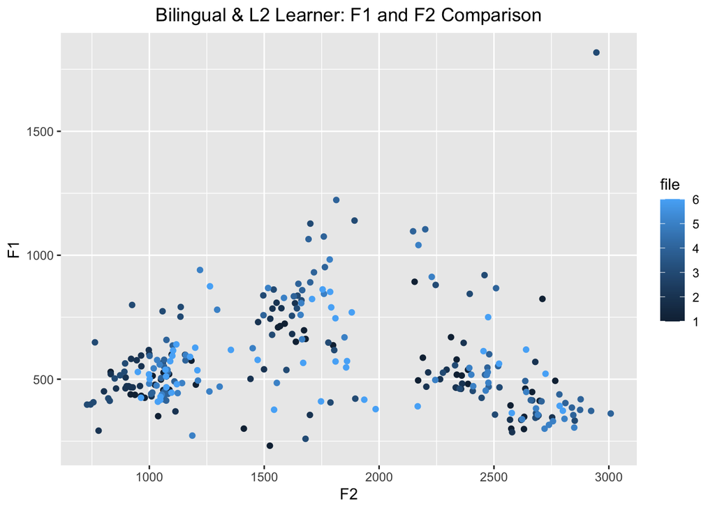

```r
all_data %>%
  ggplot(aes(y = f1, x = f2, color = file)) +
  geom_point(position = position_jitter(2), size = 1.5) +
  labs(x = "F2", y = "F1",
       title = "Bilingual & L2 Learner: F1 and F2 Comparison") +
  theme(plot.title = element_text(hjust = 0.5))
```

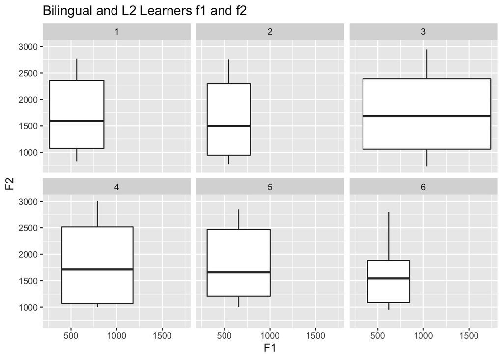

```r
all_data %>%
  ggplot(aes(x = f1, y = f2)) +
  geom_boxplot() +
  facet_wrap(vars(file)) +
  labs(x = "F1", y = "F2", title = "Bilingual and L2 Learners f1 and f2")
```

# Praat Spectogram

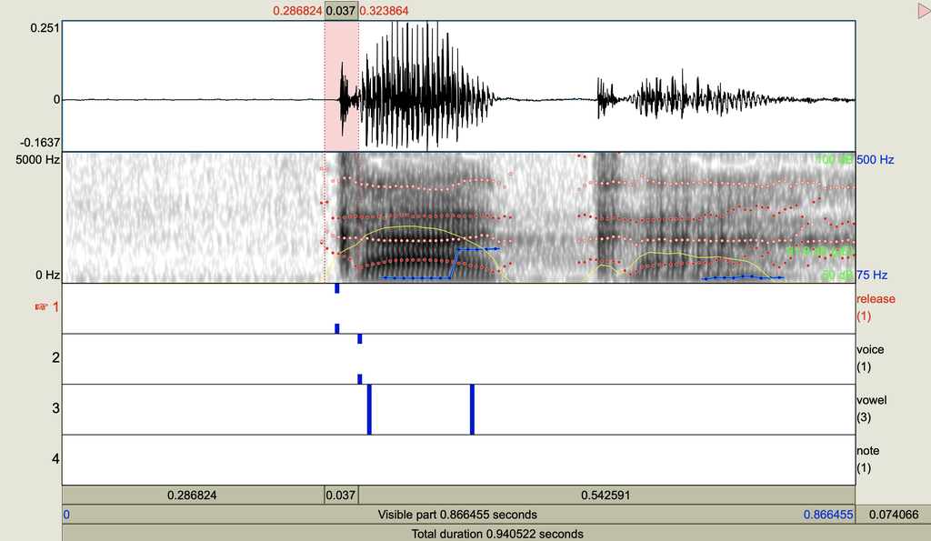

```r
url <- "https://drive.google.com/uc?export=view&id=1qJsR6By3yJ61UQ-E2NjVW8CvfCYxnyLg"
knitr::include_graphics(url, dpi = 600)
```

Figure 2. The L2 Learner participant (ne) below is producing “kaka.”

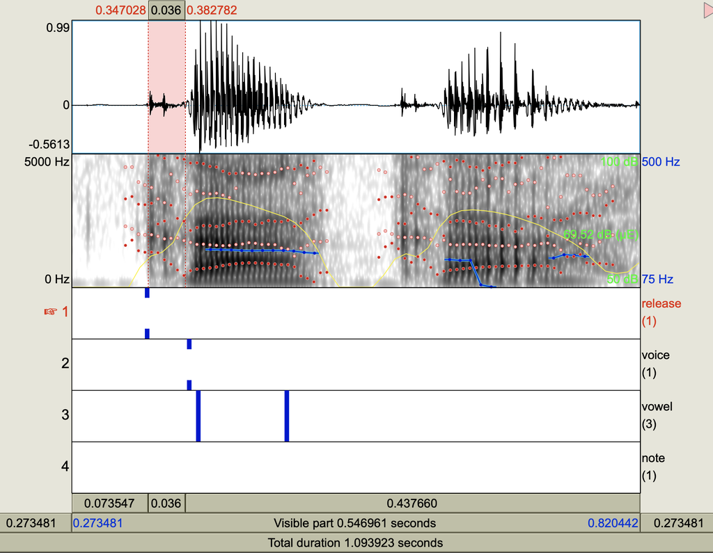

```r
url <- "https://drive.google.com/uc?export=view&id=1AX9DSa1u2ZKd8GZ_smxyjlBV-CPprxjv"
knitr::include_graphics(url, dpi = 600)
```

## Hypothesis test

```r
# Conduct a simple statistical analysis here (optional)

model <- lm(f1~f2, data=all_data)
```

# Conclusion

It is almost the end of the semester! As I reflect on my growths and glows, I have to admit that I am proud of my accomplishments. I am “more” comfortable with Rstudio and statistics but need to continue to improve in this area. I never used Praat, and it is an interesting tool with many benefits.

I know with time and practice, this will improve, but one of the things that I dislike is that it can take me hours to find a code that works or one that I properly apply. For example, I found that the Knitr::include_graphics or similar ones did not work for me. I resorted to adding the image (Praat) as a link to view it in my pa_4 report.

I had some difficulty looking for the error in the scripts from the pa-4. I was able to resolve all, but the one with the “#” error took long. The next group of students would benefit from knowing the number of errors in each script so they are not overanalyzing (and taking long) each script (like me). For example, I would suggest letting students know that there are 2 errors in scipt_1 and 1 error in script_2 would be helpful.